# STAT400-Project3

# Example(s)

```r
# This is a small demonstartion of the command replicate(). It replicates drawing a sample of size 15, 10 times
# from a normal distribution with mean 10 and variance 1. As you can see from the output, the samples appear along
# the columns as the repetitions appear along the columns.

set.seed(1)
samples <- replicate (10, rnorm(15,10,1))
samples
```

```
           [,1]      [,2]      [,3]      [,4]      [,5]      [,6]      [,7]      [,8]      [,9]     [,10]
 [1,]  9.373546  9.955066 11.358680  9.292505 12.401618 10.291446  9.457480 11.767287  9.494043  8.463550
 [2,] 10.183643  9.983810  9.897212 10.364582  9.960760  9.556708 11.207868 10.716707 11.343039  9.699024
 [3,]  9.164371 10.943836 10.387672 10.768533 10.689739 10.001105 11.160403 10.910174  9.785421  9.471720
 [4,] 11.595281 10.821221  9.946195  9.887654 10.028002 10.074341 10.700214 10.384185  9.820443  9.347905
 [5,] 10.329508 10.593901  8.622940 10.881108  9.256727  9.410479 11.586833 11.682176  9.899809  9.943103
 [6,]  9.179532 10.918977  9.585005 10.398106 10.188792  9.431331 10.558486  9.364264 10.712666  8.085641
 [7,] 10.487429 10.782136  9.605710  9.387974  8.195041  9.864821  8.723408  9.538355  9.926436 11.176583
 [8,] 10.738325 10.074565  9.940687 10.341120 11.465555 11.178087  9.426735 11.432282  9.962366  8.335028
 [9,] 10.575781  8.010648 11.100025  8.870637 10.153253  8.476433  8.775387  9.349304  9.318340  9.536470
[10,]  9.694612 10.619826 10.763176 11.433024 12.172612 10.593946  9.526599  9.792619  9.675730  8.884080
[11,] 11.511781  9.943871  9.835476 11.980400 10.475510 10.332950  9.379633  9.607192 10.060160  9.249181
[12,] 10.389843  9.844204  9.746638  9.632779  9.290054 11.063100 10.042116  9.680007  9.411106 12.087167
[13,]  9.378759  8.529248 10.696963  8.955865 10.610726  9.695816  9.089078  9.720887 10.531496 10.017396
[14,]  7.785300  9.521850 10.556663 10.569720  9.065902 10.370019 10.158029 10.494188  8.481606  8.713699
[15,] 11.124931 10.417942  9.311244  9.864945  8.746367 10.267099  9.345415  9.822670 10.306558  8.359394
```

```r
# We can cycle through the columns and calculate the average of each column as follows by looping through
# with a for loop.

for(i in 1:10) {
    cat(mean(samples[,i]), "is the average for column", i, "\n")
}
```

```
10.10084 is the average for column 1
10.06407 is the average for column 2
10.09029 is the average for column 3
10.17526 is the average for column 4
10.18004 is the average for column 5
10.04051 is the average for column 6
9.942512 is the average for column 7
10.28415 is the average for column 8
9.915281 is the average for column 9
9.424663 is the average for column 10
```

```r
# As an exercise read the documentation for the functions apply, sapply etc and see if you can rewrite
# the code to avoid the use of the for loop.
```

```r
set.seed(1)
samples <- replicate(1000, rnorm(40, 10, 1))
sample_mean <- 1:1000
for(i in 1:1000) {
    sample_mean[i] <- mean(samples[,i])
}

#Empirical verification of unbiasedness
mean(sample_mean)
```

```
[1] 9.99782
```

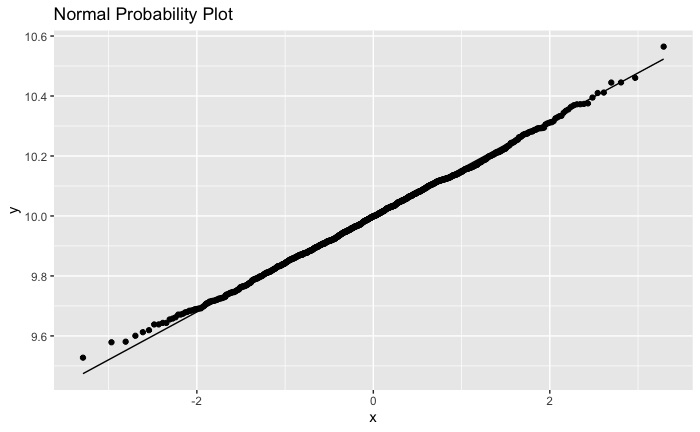

```r
#Normality plot

library(ggplot2)

# Create the normal probability plot
ggplot(data.frame(sample_mean), aes(sample = sample_mean)) +
stat_qq() +
stat_qq_line() +
labs(title = "Normal Probability Plot")
```

# 1

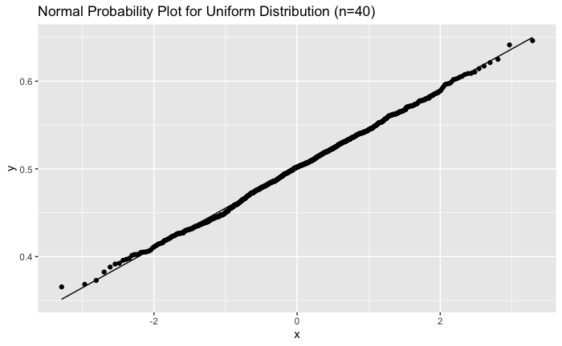

```r
## Uniform Distribution
set.seed(2)
# For size 40
samples_uniform40 <- replicate(1000, runif(40, 0, 1))
sample_means40 <- apply(samples_uniform40, 2, mean)

# For size 2
samples_uniform2 <- replicate(1000, runif(2, 0, 1))
sample_means2 <- apply(samples_uniform2, 2, mean)

# Empirical verification for size 40
ggplot(data.frame(sample_means40), aes(sample = sample_means40)) +
  stat_qq() +
  stat_qq_line() +
  labs(title = "Normal Probability Plot for Uniform Distribution (n=40)")
```

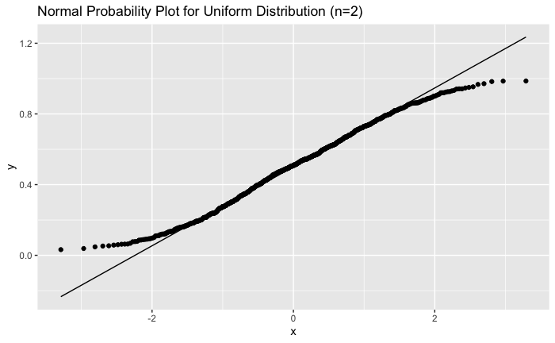

```r
# Empirical verification for size 2
ggplot(data.frame(sample_means2), aes(sample = sample_means2)) +
  stat_qq() +
  stat_qq_line() +
  labs(title = "Normal Probability Plot for Uniform Distribution (n=2)")
```

For size 40, the plot should show that sample means are approximately normal, as per the CLT. For size 2, the approximation may be poor, indicating that larger sample sizes are needed for the CLT to hold effectively.

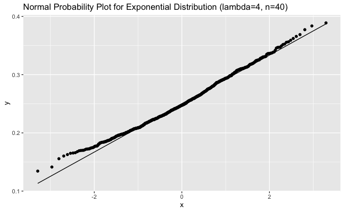

```r
## Exponential Distribution
set.seed(2)
samples_exp <- replicate(1000, rexp(40, rate = 4))
sample_means_exp <- apply(samples_exp, 2, mean)

ggplot(data.frame(sample_means_exp), aes(sample = sample_means_exp)) +
  stat_qq() +
  stat_qq_line() +
  labs(title = "Normal Probability Plot for Exponential Distribution (lambda=4, n=40)")
```

The sample means from an exponential distribution with n=40 should also exhibit normality, supporting the CLT.

# 2

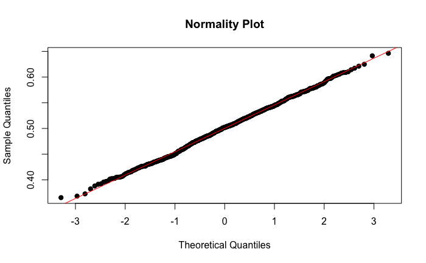

```r
normality_plot <- function(sample_means) {
  n <- length(sample_means)
  sorted_means <- sort(sample_means)
  theoretical_quantiles <- qnorm((1:n - 0.5) / n)

  plot(theoretical_quantiles, sorted_means, main = "Normality Plot",
       xlab = "Theoretical Quantiles", ylab = "Sample Quantiles", pch = 19)
  abline(lm(sorted_means ~ theoretical_quantiles), col = "red")  # Line of best fit
}

# Using the function for uniform distribution
normality_plot(sample_means40)
```

# 3(i)

For the PDF of a normal distribution given by:
$$f(x|\mu,\sigma^2)=\frac{1}{\sqrt{2\pi\sigma^2}}e^{-\frac{(x-\mu)^2}{2\sigma^2}}$$
Given a sample $X_1,X_2,...,X_n$ from this distribution, the likelihood function $L$ for the parameters $\mu$ and $\sigma^2$ based on this sample is the product of the individual densities:
$$L(\mu,\sigma^2)=\prod_{i=1}^n\frac{1}{\sqrt{2\pi\sigma^2}}e^{-\frac{(X_i-\mu)^2}{2\sigma^2}}$$
Taking the natural logarithm of the likelihood function (to obtain the log-likelihood function, which is easier to differentiate), we get:
$$\log
L(\mu,\sigma^2)=\sum_{i=1}^n\log\left(\frac{1}{\sqrt{2\pi\sigma^2}}e^{-\frac{(X_i-\mu)^2}{2\sigma^2}}\right)$$
$$=-\frac{n}{2}\log(2\pi\sigma^2)-\sum_{i=1}^n\frac{X_i-\mu)^2}{2\sigma^2}$$
To find the MLEs, we take derivatives of $\log L(\mu,\sigma^2)$ with respect to $\mu$ and $\sigma^2$, set them to zero and solve for $\mu$ and $\sigma^2$.
**Maximizing with respect to $\mu$:**
$$\frac{\partial\log
L}{\partial\mu}=\sum_{i=1}^n\frac{2(X_i-\mu)}{2\sigma^2}=0$$
$$\implies\sum_{i=1}^n(X_i-\mu)=0$$
$$\implies n\mu=\sum_{i=1}^nX_i$$
$$\implies\widehat{\mu}=\frac{\sum_{i=1}^nX_i}{n}$$
This result tells us that the MLE for $\mu$ is the sample mean.
**Maximizing with respect to $\sigma^2$:**
$$\frac{\partial\log
L}{\partial\sigma^2}=-\frac{n}{2\sigma^2}+\sum_{i=1}^n\frac{(X_i-\mu)^2}{2(\sigma^2)^2}=0$$
$$\implies-\frac{n}{2\sigma^2}+\frac{\sum_{i=1}^n(X_i-\widehat\mu)^2}{2(\sigma^2)^2}=0$$
$$\implies
n\sigma^2=\sum_{i=1}^n(X_i-\widehat\mu)^2$$
$$\implies\widehat\sigma^2=\frac{\sum_{i=1}^n(X_i-\widehat\mu)^2}{n}$$
Thus, the MLE for $\sigma^2$ is the sample variance.

# 3(ii)

```r
set.seed(2)
sample_normal <- rnorm(4000, mean = 2, sd = sqrt(5))
mu_hat <- mean(sample_normal)
sigma_squared_hat <- sum((sample_normal - mu_hat)^2) / length(sample_normal)

# Output the estimates
mu_hat
```

```
[1] 2.096682
```

```r
sigma_squared_hat
```

```
[1] 5.041896
```

# 4

```r
set.seed(2)
lambda <- 2
n <- 50
sample_expo <- replicate(10000, rexp(n, rate = lambda))
sample_means_expo <- colMeans(sample_expo)

# Standard error of the mean
se <- (1 / lambda) / sqrt(n)

# 99% Confidence interval using the normal approximation
z <- qnorm(0.995)  # Z-value for 99%
ci_lower <- sample_means_expo - z * se
ci_upper <- sample_means_expo + z * se

# Theoretical mean
theoretical_mean <- 1 / lambda

# Proportion of intervals containing the theoretical mean
ci_coverage <- mean(ci_lower <= theoretical_mean & ci_upper >= theoretical_mean)

# Display the proportion of confidence intervals that contain the theoretical mean
ci_coverage
```

```
[1] 0.9892
```

# 5

```r
data(iris)
by_species <- split(iris$Petal.Length, iris$Species)
ci_results <- lapply(by_species, function(x) {
  mu <- mean(x)
  sigma <- sd(x)
  n <- length(x)
  error <- qt(0.975, df = n - 1) * sigma / sqrt(n)
  c(lower = mu - error, upper = mu + error)
})

# Outputs
print(ci_results)
```

```
$setosa
   lower    upper
1.412645 1.511355

$versicolor
   lower    upper
4.126453 4.393547

$virginica
   lower    upper
5.395153 5.708847
```

Confidence intervals are constructed for each species’ petal length using the t-distribution, appropriate here because sample sizes may not be sufficiently large for the CLT to apply completely. This approach accounts for smaller sample sizes and the inherent variability in the data.